# Homework 2

Bohao Tang

# Part 1

The function is writen in iteration:

```r
Factorial <- function(n) {
    if(n < 0 | abs(round(n) - n) > 0)
        return(NaN)
    else {
        f = 1
        while(n > 0){
            f = f * n
            n = n - 1
        }
        return(f)
    }
}
```

Here are some tests:

```r
Factorial(4)
```

```
## [1] 24
```

```r
Factorial(0)
```

```
## [1] 1
```

```r
Factorial(-4)
```

```
## [1] NaN
```

# Part 2

In this part we design a visualizing function. The function `visual` requires packasges `readr`, `dplyr`, `ggplot2`. And it has five parameters: `id`, `visit`, `room`, `dataset` and `c_types`, where the first three specify the subset to visualize, and the last two acutually you shouldn’t change them.

In the function, I include the packages and then judge which parameters the user have put in. Whenever the user do a specification via `id`, `visit` or `room` (they can use them singlely, doublely or use then all), we do a `filter` to the data. And If the user do not specify any property, we just plot out the whole dataset. After all the `filter` function, if the projected data is null, we raise a **Wrong Factors** error, if not, we plot out the whole projected dataset.

The code is shown below:

```r
visual <- function(id, visit, room,
                   dataset="MIE.zip", c_types="cicdi") {
    library(readr)
    library(dplyr)
    library(ggplot2)

    mie <- read_csv(dataset, col_types = c_types)

    mie.sub <- mie
    title = ''

    if(!hasArg(id) & !hasArg(visit) & !hasArg(room))
        qplot(timepoint, value, data = mie) + ggtitle("All Data")

    else{
        if(hasArg(id)){
            input_id = as.character(id)
            mie.sub <- filter(mie.sub, id == input_id)
            title = paste(title, sprintf(" id = %s",id))
        }
        if(hasArg(visit)){
            input_visit = int(visit)
            mie.sub <- filter(mie.sub, visit == input_visit)
            title = paste(title, sprintf(" visit = %s",visit))
        }
        if(hasArg(room)){
            input_room = as.character(room)
            mie.sub <- filter(mie.sub, room == input_room)
            title = paste(title, sprintf(" room = %s",room))
        }
        if(count(mie.sub) == 0)
            stop("Wrong Factors!\n")

        qplot(timepoint, value, data = mie.sub) + ggtitle(title)
    }
}
```

Here are some tests:

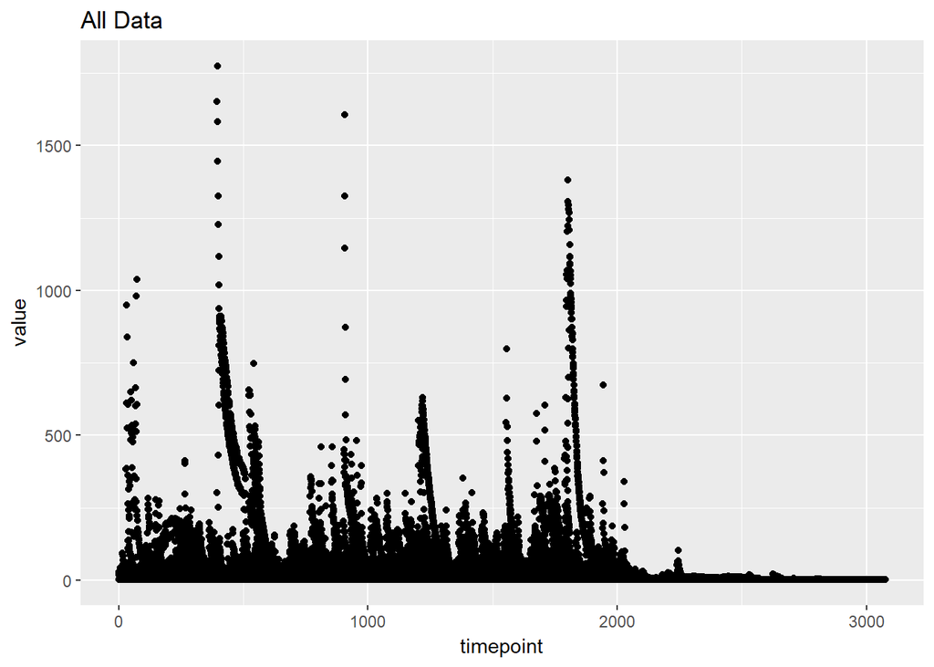

```r
visual()
```

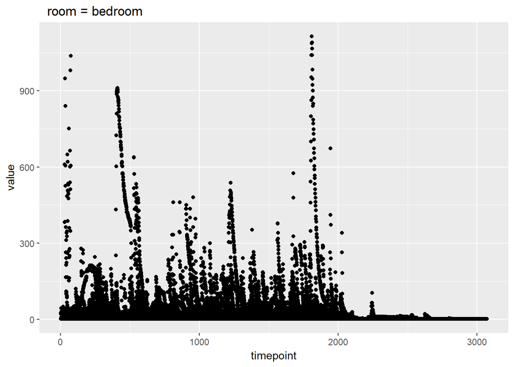

```r
visual(room="bedroom")
```

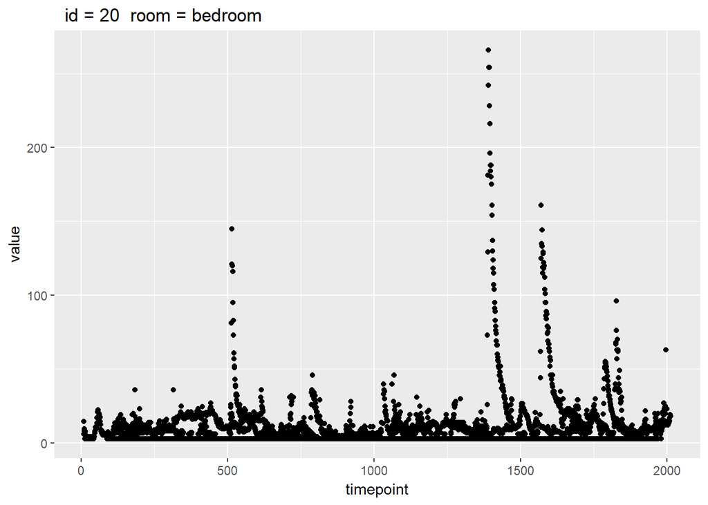

```r
visual(id=20, room="bedroom")
```

# Part 3

In this part, I wrote an function called `bootstrap.med.ci` to compute the ci of median via bootstrap method. The function have three parameters: `data`, `times` and `level`. The function will find `level` level of confidential interval of the `data` by resampling it `times` times.

In the function, I changed the data to `numeric` type and remove the `NA` part. So if the data can not be change to `numeric` type or you consider the `NA` should be dealed in another way, you should not use my function.

The output is of the structure of percentages along with interval end points. Typically the second line of output will be the two end points of the ci.

The code is shown below:

```r
source("median_testdata.R")

bootstrap.med.ci <- function(data, times=1000, level=0.95) {
    medians = c()
    data = as.numeric(data)
    data.aux = data[!is.na(data)]
    for(it in 1:times){
        samples = sample(data.aux, replace = TRUE)
        medians = c(medians, median(samples))
    }
    q1 = (1 - level) / 2; q2 = (1 + level) / 2
    c(quantile(medians, q1), quantile(medians, q2))
}
```

Here are some tests:

```r
bootstrap.med.ci(x1)
```

```
##       2.5%      97.5%
## -0.3788283  0.0601523
```

```r
bootstrap.med.ci(x2)
```

```
##     2.5%    97.5%
## 13.44487 15.76999
```

```r
bootstrap.med.ci(x3)
```

```
##       2.5%      97.5%
## -0.9939697  1.2162569
```

```r
bootstrap.med.ci(x4)
```

```
##      2.5%     97.5%
## 0.7916612 0.8636303
```

```r
bootstrap.med.ci(x5)
```

```
##  2.5% 97.5%
##     5    15
```